# Bareroot Experiment @ Fleming’s Nurseries

Court Campany & Leanne Gillies

## Summary

I split off the first set of measurements before planting in 45L. This makes sense for several reasons. It is good to have time0 measurements, which we do. It takes away the issue with caliper measurement locations before and after planting. We can analyze the two sets of data separately. We need to work on the methods. Specifically, a brief (1 paragraph) description of the bare root production process to grow the trees before we planted them. We will also need information on the soil used and the fertilization/water regime. We can add that to details below.

## Experimental design

# Results (ongoing)

Ill start running stats in the near future on the time0 trees. We will want to determine how species, varieties within species, and grades differ. For the industry, we can focus on “Size Index” if you want and/or on the allometric components height and diameter. We could also use stem volume (d^2h) as it makes a meaningful comparison to the container volume.

## Pre-planting bareroot data

Here you clearly see how some species/varieties are inherently different. You can also see the clear difference in grade on size index. Importantly, both height and caliper differ to start.

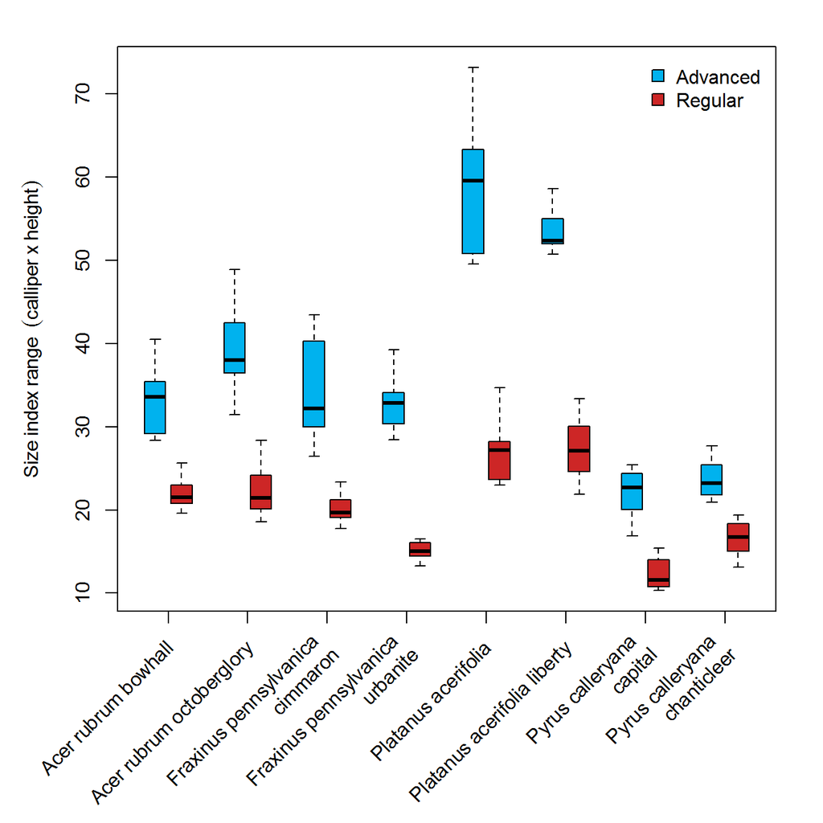

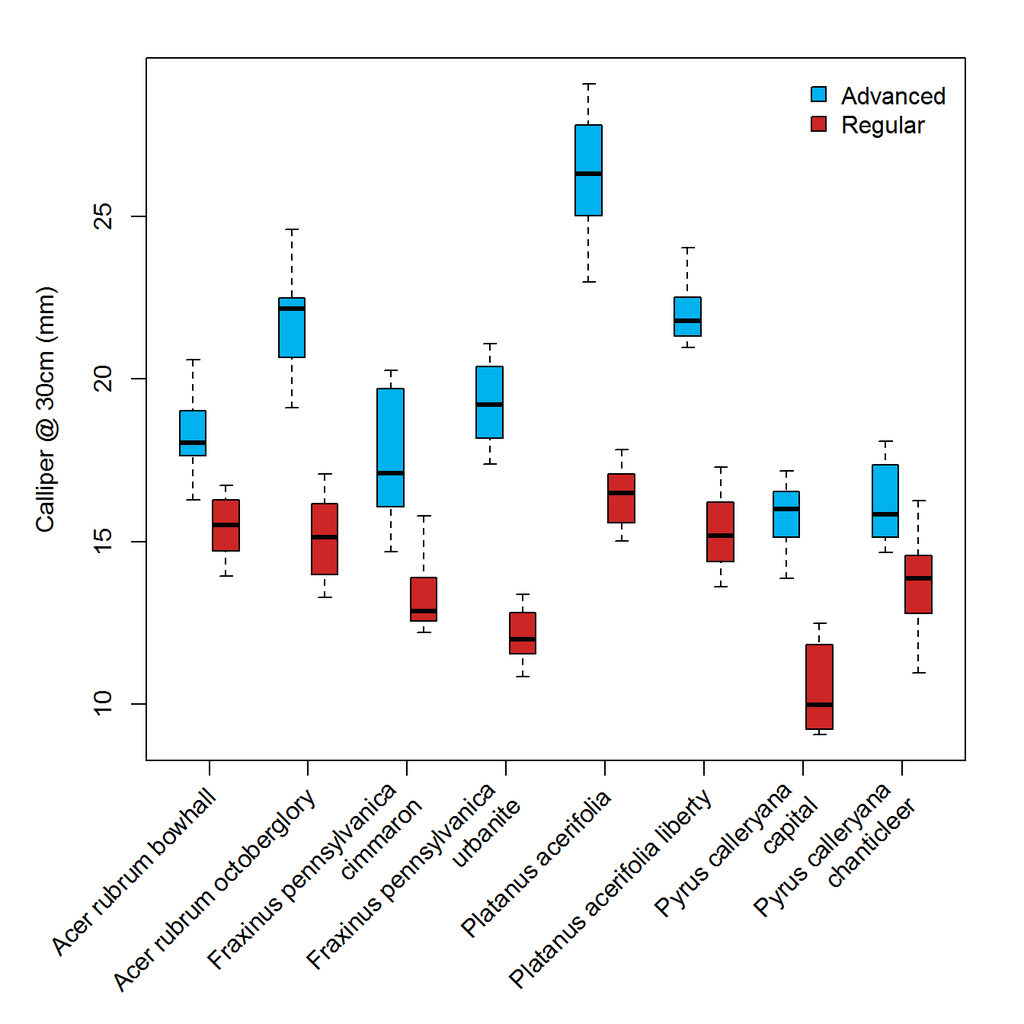

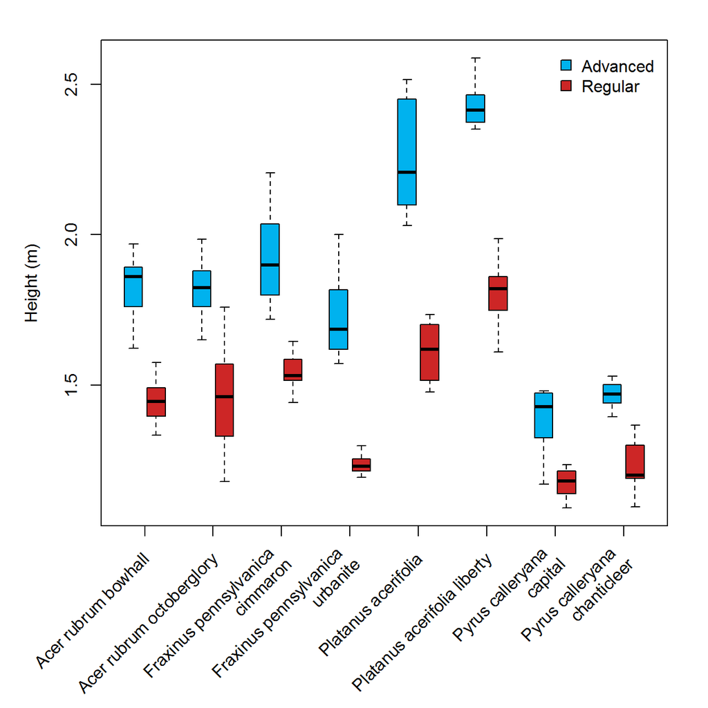

## Growth and morphology metrics

Below are the mean + standard error for each individual batch of trees. It seems that the rate of height growth in regular trees may be slightly higher and these trees seem to have caught up by February. This last date is intersting though. It will be interesting what the new data show, as it apperas Advanced trees are leveling off. It appears that grade has a more lasting effect on caliper. Although the rate of caliper expansion seems to be greater in Regular trees they still havent caught up by February (~20 vs ~25). Overall, Advanced trees still have a higher size index than Regular trees at this point (~70 vs ~55) due to the differences in calliper. It will be very interesting to see what the final numbers on when we terminate.

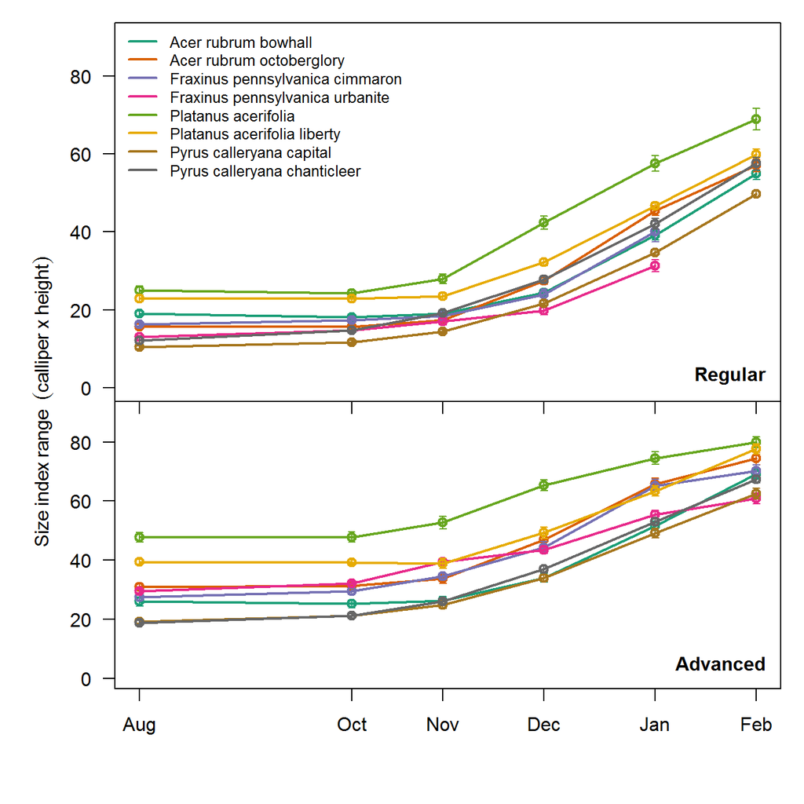

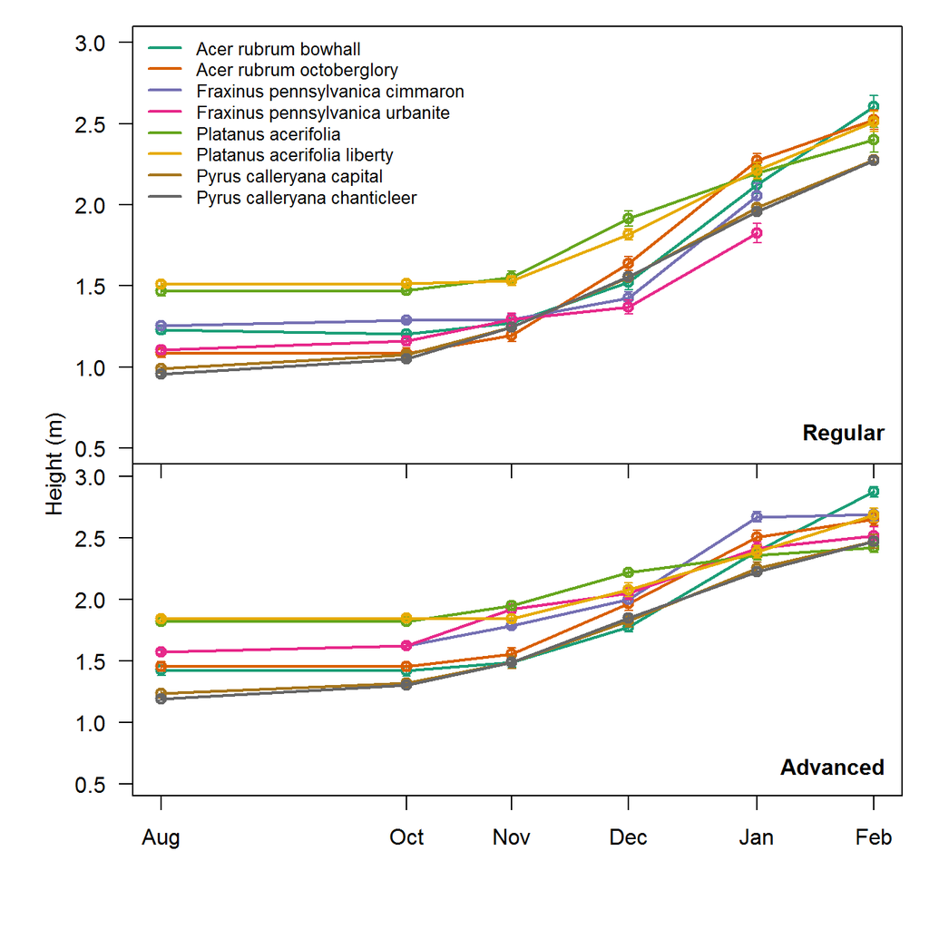

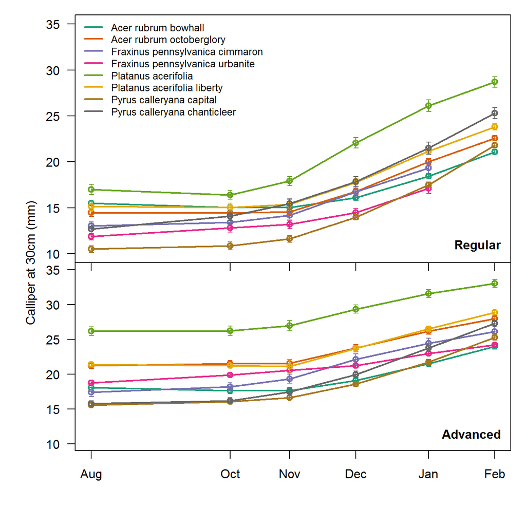